# Machine Learning Project

Javier Eslava-Schmalbach

8/11/2018

### Background from the assignment

“Using devices such as Jawbone Up, Nike FuelBand, and Fitbit it is now possible to collect a large amount of data about personal activity relatively inexpensively. These type of devices are part of the quantified self movement – a group of enthusiasts who take measurements about themselves regularly to improve their health, to find patterns in their behavior, or because they are tech geeks. One thing that people regularly do is quantify how much of a particular activity they do, but they rarely quantify how well they do it. In this project, your goal will be to use data from accelerometers on the belt, forearm, arm, and dumbell of 6 participants. They were asked to perform barbell lifts correctly and incorrectly in 5 different ways. More information is available from the website here: http://groupware.les.inf.puc-rio.br/har (see the section on the Weight Lifting Exercise Dataset)”

### Objective

The goal of this project is to predict the manner in which tech geeks did the exercise using the “classe” variable as the outcome to be predicted

### Methodology

Databases will be downloaded from url addresses provided in the assignment: one for training and getting the best model and the second for predicting the behaviour of 20 specific cases. After that, they will be cleaned in the same way, deleting variables with NA values, Near Zero Variance, and not relevant with the objective. The training dataset will be splited in two subsets to facilitate cross-validation: training and testing data sets. All models will be tested in this testing dataset, and the best of all, will be used to predict the behaviour of cases of the test dataset provided for the exercise. A graphic comparison will be done with clusters got from the data in both datasets. In all models accuracy will be measured comparing their results with variable “class” of the subset(training). To evaluate accuracy in the test dataset, 20 randomly cases will be selected from the training dataset, and their respective “classe” values will be used to compare the predictive results in the Test dataset (as a second process of cross-validation), given that, this data did not have included the “class”" of the subjects.

### Development

#### Getting the databases

```r
       training <- read.csv(url("https://d396qusza40orc.cloudfront.net/predmachlearn/pml-training.csv"), header = TRUE, sep=",", na.strings=c("NA","#DIV/0!",""))
        test <- read.table(url("https://d396qusza40orc.cloudfront.net/predmachlearn/pml-testing.csv"), sep = ",", header = TRUE, na.strings=c("NA","#DIV/0!",""))
```

#### Cleaning and deleting Near Zero Variance, NA and non relevant variables

```r
        ## library(lubridate)
       dimension1 <- data.frame(cbind(dim(training), dim(test)))
        colnames(dimension1) <- c("initial dim training", "initial dim testing")
        rownames(dimension1) <- c("rows", "columns")
        dimension1
```

```
        initial dim training initial dim testing
rows                   19622                  20
columns                  160                 160
```

```r
          ## deleting columns with NA values
        training <- training[,colSums(is.na(training)) == 0]
        test <- test[,colSums(is.na(test)) == 0]

         ## removing near zero covariance variables
        nsv <- nearZeroVar(training,saveMetrics=TRUE)

        ## removing first 5 variables, that include new window that it is a noon zero variance variable
        training <- training[,-c(1:6)]
        test <- test[,-c(1:6)]

        ## dimensions after cleaning
         dimension2 <- data.frame(cbind(dim(training), dim(test)))
        colnames(dimension2) <- c("after dim training", "after dim testing")
        rownames(dimension2) <- c("rows", "columns")
        dimension2
```

```
        after dim training after dim testing
rows                 19622                20
columns                 54                54
```

#### Subsetting a database from the training dataset to test and cross-validate initial findings. Test database will be used to final validation

```r
        set.seed(1234)
        inTrain <- createDataPartition(y=training$classe, p=0.7, list=FALSE)
        training1 = training[inTrain,]
        testing1 = training[-inTrain,]  ## from the training database

        dimension3 <- data.frame(cbind(dim(training1), dim(testing1)))
        colnames(dimension3) <- c("subset(training)", "subset(testing)")
        rownames(dimension3) <- c("rows", "columns")
        dimension3
```

```
        subset(training) subset(testing)
rows               13737            5885
columns               54              54
```

#### Looking for the best model

```r
        modFit.rpart <- train(classe ~., method = "rpart",data=training1)
        modFit.rf <-  train(classe ~., method = "rf",data=training1)
        modFit.gbm <-  train(classe ~., method = "gbm",data=training1, verbose = FALSE)
        modFit.lda <- train(classe ~., method = "lda",data=training1)

        predict.rpart <- predict(modFit.rpart, testing1)
        predict.rf <- predict(modFit.rf, testing1, type = "raw")
        predict.gbm <- predict(modFit.gbm, testing1)
        predict.lda <-  predict(modFit.lda, testing1)

        y <- testing1$classe
        accuracies <- data.frame(cbind(postResample(predict.rpart, y),
        postResample(predict.rf, y),
        postResample(predict.gbm, y),
        postResample(predict.lda, y)))
        colnames(accuracies) <- c("RPART model", "RF model", "GBM model", "LDA model")
        accuracies
```

```
         RPART model  RF model GBM model LDA model
Accuracy   0.4890399 0.9981308 0.9887850 0.7184367
Kappa      0.3311096 0.9976356 0.9858103 0.6435904
```

The bests models are Random Forest and Gradient Boosting Nachine (GBM). However, Random Forest is less time-consuming, and this model is seleted then, to be cross-validated in the Test dataset.

#### Characteristics of the selected model

```r
        modFit.rf$finalModel
```

```
Call:
 randomForest(x = x, y = y, mtry = param$mtry)
               Type of random forest: classification
                     Number of trees: 500
No. of variables tried at each split: 27

        OOB estimate of  error rate: 0.23%
Confusion matrix:
     A    B    C    D    E  class.error
A 3904    1    0    0    1 0.0005120328
B    4 2650    3    1    0 0.0030097818
C    0    5 2390    1    0 0.0025041736
D    0    0    8 2243    1 0.0039964476
E    0    1    0    6 2518 0.0027722772
```

```r
        importance <- data.frame(round(importance(modFit.rf$finalModel, 2), 2))
        importance
```

```
                     MeanDecreaseGini
num_window                    2001.93
roll_belt                     1282.42
pitch_belt                     565.28
yaw_belt                       677.28
total_accel_belt                57.80
gyros_belt_x                    29.41
gyros_belt_y                    40.45
gyros_belt_z                   101.71
accel_belt_x                    30.51
accel_belt_y                    46.82
accel_belt_z                   189.66
magnet_belt_x                  124.44
magnet_belt_y                  159.01
magnet_belt_z                  173.87
roll_arm                       104.51
pitch_arm                       64.86
yaw_arm                         80.14
total_accel_arm                 31.27
gyros_arm_x                     34.90
gyros_arm_y                     47.20
gyros_arm_z                     14.35
accel_arm_x                     87.16
accel_arm_y                     41.80
accel_arm_z                     37.51
magnet_arm_x                    64.42
magnet_arm_y                    67.38
magnet_arm_z                    47.69
roll_dumbbell                  216.22
pitch_dumbbell                  61.81
yaw_dumbbell                   108.61
total_accel_dumbbell           202.19
gyros_dumbbell_x                36.11
gyros_dumbbell_y                85.91
gyros_dumbbell_z                23.01
accel_dumbbell_x                94.15
accel_dumbbell_y               255.95
accel_dumbbell_z               158.50
magnet_dumbbell_x              234.08
magnet_dumbbell_y              587.69
magnet_dumbbell_z              575.36
roll_forearm                   427.22
pitch_forearm                  774.84
yaw_forearm                     75.90
total_accel_forearm             31.26
gyros_forearm_x                 16.96
gyros_forearm_y                 32.86
gyros_forearm_z                 25.65
accel_forearm_x                209.42
accel_forearm_y                 38.04
accel_forearm_z                 97.68
magnet_forearm_x                73.43
magnet_forearm_y                73.51
magnet_forearm_z               139.85
```

The most important variables in the model are num_window, roll belt and pitch forearm

#### Plotting prediction and clustering results against original class variable

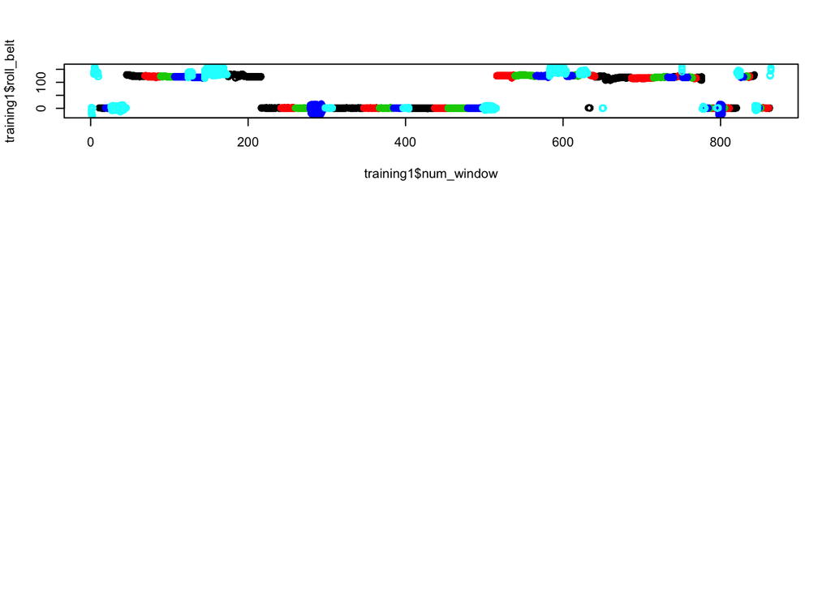

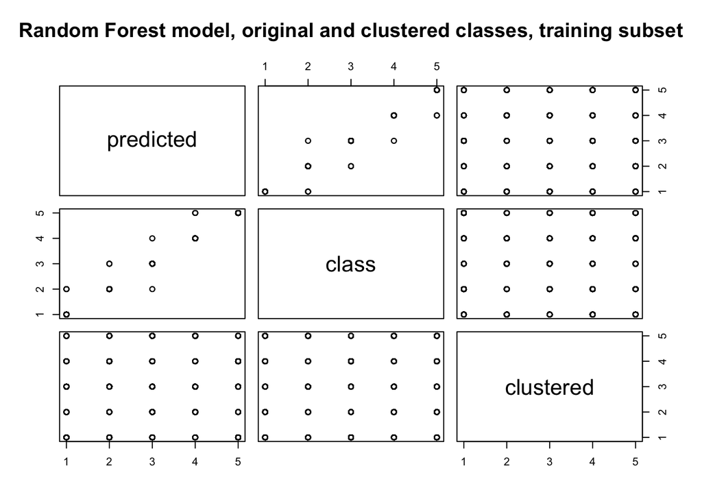

```r
        ## library(kernlab); library(ade4)

        training1s <- subset(training1, select=-c(54))

        kmeans1 <- kmeans(na.omit(training1s),centers=5)
        kmeansRes<-factor(kmeans1$cluster)


        combined <- data.frame(cbind(predicted=predict.rf, class=y, clustered=kmeans1$cluster))

        testing1s <- subset(testing1, select=-c(54))
        kmeans2 <- kmeans(na.omit(testing1s),centers=5)
        kmeansRes2<-factor(kmeans2$cluster)


        combined <- data.frame(cbind(predicted=predict.rf, class=y, clustered=kmeans1$cluster))
        plot.new()
        par(mfrow = c(3,1));

        plot(training1$num_window, training1$roll_belt, col=training1$classe)
        plot(combined, main="Random Forest model, original and clustered classes, training subset")
```

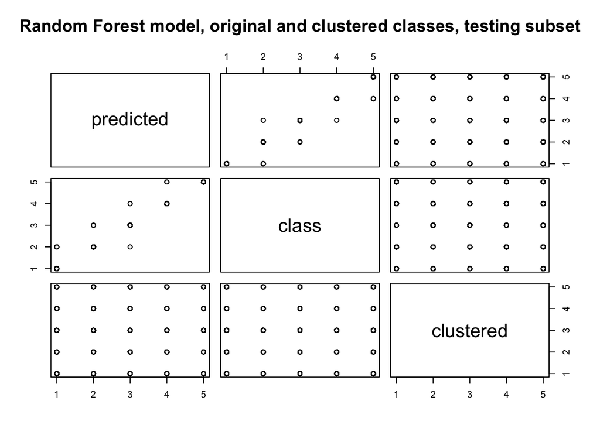

```r
        plot(combined, main="Random Forest model, original and clustered classes, testing subset")
```

In the Figure is evident that Cluster analysis could not identify as good as Random Forest does, the classes of subjects.

#### Prediction of Cases in the data, and accuracy of the Random Forest model, using 20 classes selected randomly from the training dataset.

```r
        set.seed(123) ## selecting a sample of 20 classes from the training dataset

        training20 <- dplyr::sample_n(training, 20)
        y <- training20$classe

        predict.rparttest <- predict(modFit.rpart, test)
        predict.rftest <- predict(modFit.rf, test, type = "raw")
        predict.gbmtest <- predict(modFit.gbm, test)
        predcit.ldatest <-  predict(modFit.lda, test)


        accuracies1 <- data.frame(cbind(postResample(predict.rparttest, y),
        postResample(predict.rftest, y),
        postResample(predict.gbmtest, y),
        postResample(predcit.ldatest, y)))
        colnames(accuracies1) <- c("RPART model", "RF model", "GBM model", "LDA model")
        accuracies1
```

```
         RPART model   RF model  GBM model    LDA model
Accuracy  0.15000000 0.25000000 0.25000000  0.200000000
Kappa    -0.03343465 0.02912621 0.02912621 -0.009463722
```

#### Cross-vallidation with the Test dataset, and prediction of the 20 cases

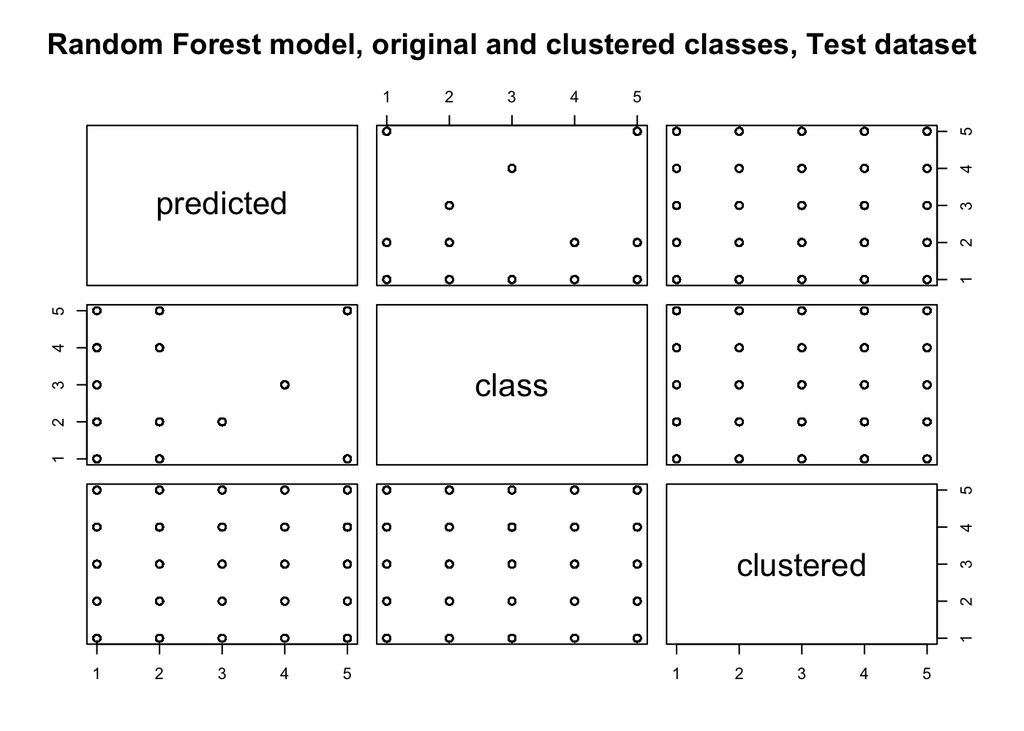

```r
        kmeans2 <- kmeans(testing1s,centers=5)
        kmeansRes2<-factor(kmeans2$cluster)
        plot.new()
         par(mfrow = c(1,1))


        combined <- data.frame(cbind(predicted=predict.rftest, class=y, clustered=kmeans2$cluster))
        plot(combined, main="Random Forest model, original and clustered classes, Test dataset")
```

Prediction is not as good as it was in the training dataset, using the Test Dataset

With the results of this predictive random forest analysis, the quiz of 20 cases was answered.

#### Acknowledgments.

To the developers of the original research available (here)[http://groupware.les.inf.puc-rio.br/har], in the section on the “Weight Lifting Exercise Dataset”